# Project Foundations for Data Science: FoodHub Data Analysis

# Observation of Delivery Time

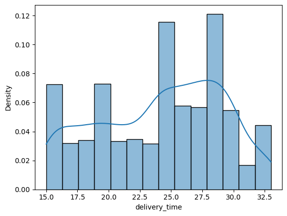

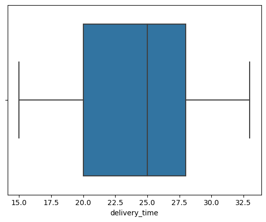

```python
sns.histplot(data=df,x='delivery_time',stat='density', kde=True)
plt.show()
sns.boxplot(data=df,x='delivery_time')
plt.show()
```

- The distribution is skewed towards left.
- There are no outliers present in this column from the boxplot
  - min=15.0
  - 25 percentile = 20.0
  - 50 percentile = 25.0
  - 75 percentile = 28.0
  - max = 33.0
  - mean = 24.2

# Let's plot the countplot of all **categorical** variables to check the distribution of the data

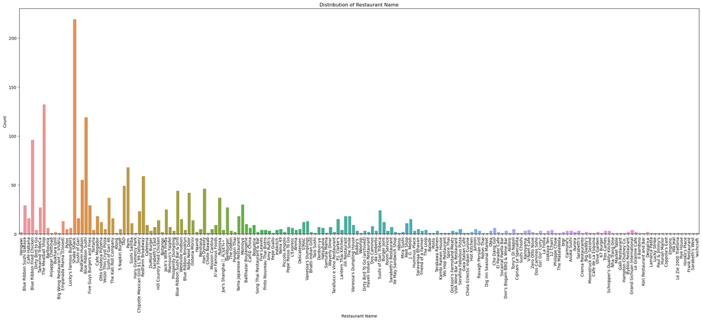

```python
# plot the countplot of categorical variable restaurant name to check the distribution of the data
import warnings
warnings.filterwarnings('ignore')

plt.figure(figsize=(30, 10))
sns.countplot(data=df, x='restaurant_name')
plt.title('Distribution of Restaurant Name')
plt.xlabel('Restaurant Name')
plt.ylabel('Count')
plt.xticks(rotation=90)
plt.show()
```

Above plot shows all restaurant name to check the distribution of the data. **Shake Shack** has highest number of count as shown.

# **Categorical distributions (non numerical values)**

- Cuisine Type
- Day of the Week
- Rating

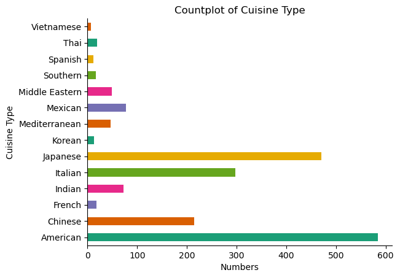

```python
# from matplotlib import pyplot as plt
# import seaborn as sns
col_name = 'cuisine_type'
df.groupby(col_name).size().plot(kind='barh', color=sns.palettes.mpl_palette('Dark2'))
plt.title("Countplot of Cuisine Type")
plt.xlabel("Numbers")
plt.ylabel("Cuisine Type")
plt.gca().spines[['top', 'right',]].set_visible(False)
```

**American** has the highest number of count, then followed by **Japanese**, and then **Italian** cuisine

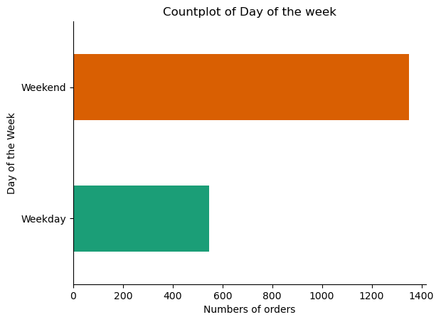

```python
# from matplotlib import pyplot as plt
# import seaborn as sns
col_name = 'day_of_the_week'
df.groupby(col_name).size().plot(kind='barh', color=sns.palettes.mpl_palette('Dark2'))
plt.title("Countplot of Day of the week")
plt.xlabel("Numbers of orders")
plt.ylabel("Day of the Week")
plt.gca().spines[['top', 'right',]].set_visible(False)
```

**Weekend** has more orders than weekday

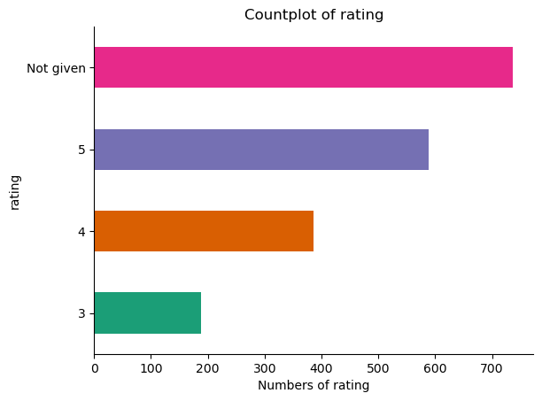

```python
# from matplotlib import pyplot as plt
# import seaborn as sns
col_name = 'rating'
df.groupby(col_name).size().plot(kind='barh', color=sns.palettes.mpl_palette('Dark2'))
plt.title("Countplot of " + col_name)
plt.xlabel("Numbers of " + col_name)
plt.gca().spines[['top', 'right',]].set_visible(False)
```

#### Observations:

- Restaurant named "Shake Shack" has highest number of count as shown.
- American has the highest number of count, then followed by Japanese, and then Italian cuisine.
- Weekend has more orders than weekdays
- Large number of "Not given" is found from the rating variable.
- Rating of 1 and 2 are not found.

### **Question 7**: Which are the top 5 restaurants in terms of the number of orders received?

```python
# top 5 restaurants in terms of the number of orders received
# df['restaurant_name'].value_counts().head(5)
print("The top 5 restaurants in terms of the number of orders received are:")
print(df['restaurant_name'].value_counts().head(5))
```

```
The top 5 restaurants in terms of the number of orders received are:
Shake Shack                  219
The Meatball Shop            132
Blue Ribbon Sushi            119
Blue Ribbon Fried Chicken     96
Parm                          68
Name: restaurant_name, dtype: int64
```

#### Observations:

- Shake Shack has highest number of order, which is 219

### **Question 8**: Which is the most popular cuisine on weekends?

```python
# most popular cuisine on weekends
# df['cuisine_type'].value_counts()
most_popular_cuisine = df[df['day_of_the_week'] == 'Weekend']['cuisine_type'].value_counts().idxmax()

# Print the result
print("The most popular cuisine on weekends is:", most_popular_cuisine)
```

```
The most popular cuisine on weekends is: American
```

#### Observations:

- American is the most popular cuisine on weekends

### **Question 9**: What percentage of the orders cost more than 20 dollars?

```python
# Calculate the percentage of orders costing more than 20 dollars
percentage = (df[df['cost_of_the_order'] > 20]['order_id'].count() / df['order_id'].count()) * 100

# Print the result
print("Percentage of orders costing more than 20 dollars: {:.2f}%".format(percentage))
```

```
Percentage of orders costing more than 20 dollars: 29.24%
```

#### Observations:

- About 29% of order costing more than 20 dollars

### **Question 10**: What is the mean order delivery time?

```python
# Calculate the mean order delivery time
mean_delivery_time = df['delivery_time'].mean()

# Print the result
print("Mean order delivery time: {:.2f} minutes".format(mean_delivery_time))
```

```
Mean order delivery time: 24.16 minutes
```

#### Observations:

- Average delivery time is 24 minutes

### **Question 11:** The company has decided to give 20% discount vouchers to the top 3 most frequent customers. Find the IDs of these customers and the number of orders they placed

```python
# Find the IDs of top 3 most frequent customers and the number of orders they placed
print("The IDs of the top 3 most frequent customers are:")
df['customer_id'].value_counts().head(3)
```

```
The IDs of the top 3 most frequent customers are:
```

```
52832    13
47440    10
83287     9
Name: customer_id, dtype: int64
```

#### Observations:

- Customer with ID : 52832, 47440, and 83287 will get the 20% discount vouchers

### **Question 12**: Perform a multivariate analysis to explore relationships between the important variables in the dataset. (It is a good idea to explore relations between numerical variables as well as relations between numerical and categorical variables)

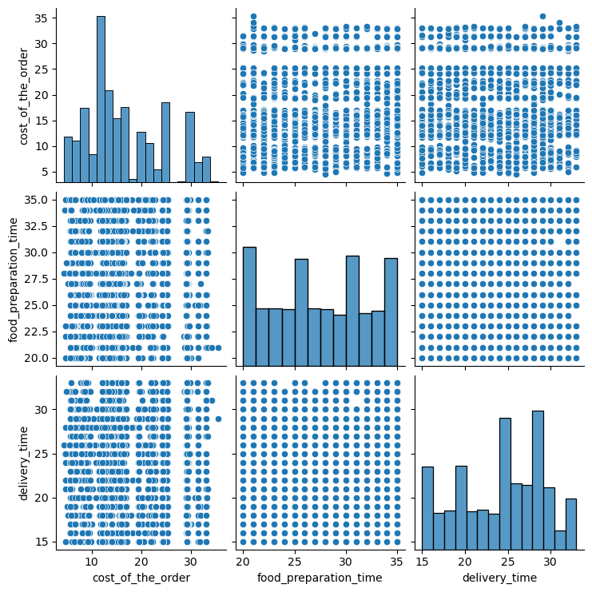

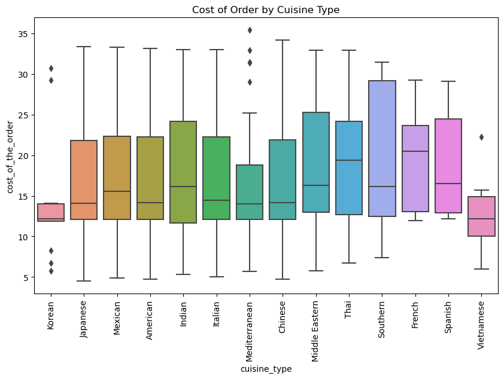

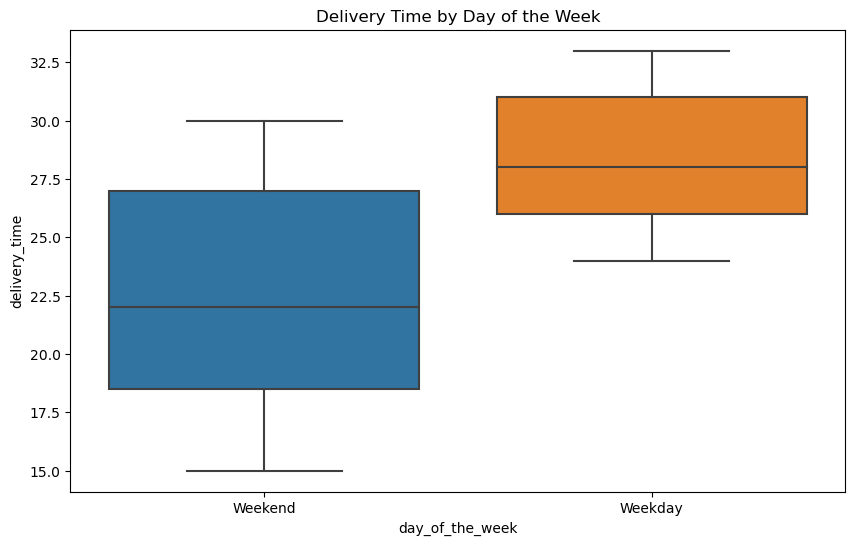

```python
# Explore relationships between numerical variables
sns.pairplot(df[['cost_of_the_order', 'food_preparation_time', 'delivery_time', 'rating']])
plt.show()

# Explore relationships between numerical and categorical variables
plt.figure(figsize=(10, 6))
sns.boxplot(x='cuisine_type', y='cost_of_the_order', data=df)
plt.xticks(rotation=90)
plt.title('Cost of Order by Cuisine Type')
plt.show()

plt.figure(figsize=(10, 6))
sns.boxplot(x='day_of_the_week', y='delivery_time', data=df)
plt.title('Delivery Time by Day of the Week')
plt.show()
```

### **Question 13:** The company wants to provide a promotional offer in the advertisement of the restaurants. The condition to get the offer is that the restaurants must have a rating count of more than 50 and the average rating should be greater than 4. Find the restaurants fulfilling the criteria to get the promotional offer

```python
# Convert the 'rating' column to numeric, handling non-numeric values
df['rating'] = pd.to_numeric(df['rating'], errors='coerce')

# Calculate the count of ratings and average rating for each restaurant
restaurant_stats = df.groupby('restaurant_name')['rating'].agg(['count', 'mean'])

# Filter restaurants based on the criteria
eligible_restaurants = restaurant_stats[(restaurant_stats['count'] > 50) & (restaurant_stats['mean'] > 4)]

# Print the eligible restaurants
print(eligible_restaurants)
```

```
                           count      mean
restaurant_name
Blue Ribbon Fried Chicken     64  4.328125
Blue Ribbon Sushi             73  4.219178
Shake Shack                  133  4.278195
The Meatball Shop             84  4.511905
```

#### Observations:

**Reference** stackoverflow.com/questions/61619006/average-rating-query

### **Question 14:** The company charges the restaurant 25% on the orders having cost greater than 20 dollars and 15% on the orders having cost greater than 5 dollars. Find the net revenue generated by the company across all orders

```python
# Calculate revenue from orders costing more than 20 dollars by 25%
revenue_above_20 = df[df['cost_of_the_order'] > 20]['cost_of_the_order'].sum() * 0.25

# Calculate revenue from orders costing more than 5 dollars (and less than or equal to 20 dollars) by 15%
revenue_above_5 = df[(df['cost_of_the_order'] > 5) & (df['cost_of_the_order'] <= 20)]['cost_of_the_order'].sum() * 0.15

# Calculate total net revenue
total_revenue = revenue_above_20 + revenue_above_5

# Print the total net revenue
print("Net revenue generated by the company: ${:.2f}".format(total_revenue))
```

```
Net revenue generated by the company: $6166.30
```

#### Observations:

- Total revenue with cost above \$20 and \$5 combined to \$6,166

### **Question 15:** The company wants to analyze the total time required to deliver the food. What percentage of orders take more than 60 minutes to get delivered from the time the order is placed? (The food has to be prepared and then delivered)

```python
# Calculate total delivery time
df['total_time'] = df['food_preparation_time'] + df['delivery_time']

# Calculate the percentage of orders taking more than 60 minutes
percentage = (df[df['total_time'] > 60]['order_id'].count() / df['order_id'].count()) * 100

# print calculated percentage
print("Percentage of orders taking more than 60 minutes to delivered: {:.2f}%".format(percentage))
```

```
Percentage of orders taking more than 60 minutes to delivered: 10.54%
```

#### Observations:

- About 10.5 % of orders taking more that an hour to delivered

### **Question 16:** The company wants to analyze the delivery time of the orders on weekdays and weekends. How does the mean delivery time vary during weekdays and weekends?

```python
# prompt: The company wants to analyze the delivery time of the orders on weekdays and weekends. How does the mean delivery time vary during weekdays and weekends?

# Calculate the mean delivery time for weekdays
weekday_delivery_time = df[df['day_of_the_week'] == 'Weekday']['delivery_time'].mean()

# Calculate the mean delivery time for weekends
weekend_delivery_time = df[df['day_of_the_week'] == 'Weekend']['delivery_time'].mean()

# Print the results
print("Mean delivery time on weekdays: {:.2f} minutes".format(weekday_delivery_time))
print("Mean delivery time on weekends: {:.2f} minutes".format(weekend_delivery_time))
```

```
Mean delivery time on weekdays: 28.34 minutes
Mean delivery time on weekends: 22.47 minutes
```